# **Module M.6** Generalized linear models

Alexis A. Diaz, Raisa Hernández-Pacheco, Alexandra L. Bland, Alexandra G. Rosati

Introduction to Primate Data Exploration and Linear Modeling with R

Introduction: *Generalized linear models* (GLMs) are a general extension of simple linear regression models that can account for multiple family distributions in the response variable, other than the Gaussian distribution. Usually, GLMs consider distributions from an exponential family (e.g., binomial, Poisson). In this way, GLMs provide a flexible modeling framework when analyzing binary, count, and proportion data. Because many life history traits such as the event of surviving or reproducing in a given season are binomial processes, GLMs represent a fundamental tool in modern population biology.

In this module, you will expand your skills on linear models (**Module M.4**) to GLMs while testing associations between Cayo Santiago rhesus macaque fitness components and cognitive health.

**Upon completion of this module, you will be able to:**

- Fit generalized linear models in **R**;
- Interpret model output;
- Plot model predictions.

**References:**

- [ggplot2](https://cran.r-project.org/web/packages/ggplot2/index.html)
- [RStudio](https://posit.co/products/open-source/rstudio/)
- [sjPlot: Data Visualization for Statistics in Social Science](https://cran.r-project.org/web/packages/sjPlot/index.html)
- [Tidyverse R packages for data science](https://www.tidyverse.org)

**Extra training:**

- [Quantifying Health, 2023](https://quantifyinghealth.com/interpret-logistic-regression-coefficients/)

**Associated literature and data:**

- [Rosati et al. 2018. Developmental shifts in social cognition: socio-emotional biases across the lifespan in rhesus monkeys](https://sites.lsa.umich.edu/cognitive-evolution/wp-content/uploads/sites/501/2018/09/2018-Rosati_et_al-socioemotional-biases.pdf)
- [Rosati et al. 2018. Data from: Developmental shifts in social cognition: socio-emotional biases across the lifespan in rhesus monkeys](https://datadryad.org/stash/dataset/doi:10.5061/dryad.9s5p4k1)

**Expand for R Notation and functions index**

**Notation:**

- **[]** for subsets by columns;
- **$** for extracting by name or creating a variable in a data frame.

**Commands:**

- Base R:
  - **glm()** for fitting generalized linear models;
  - **install.packages()** for installing packages;
  - **library()** for loading packages;
  - **summary()** for model output.
- ggplot2:
  - **geom_ ()** functions for the plot type.
- sjPlot:
  - **plot_model()** for plotting model predictions.
- tidyverse:
  - **filter()** for filtering data frames by row.

### Testing associations between fitness and cognitive health

Rhesus macaques possess sophisticated human-like cognitive traits that are relevant to aging and other demographic processes. These traits include both socioemotional cognition and several aspects of executive functions and decision-making. However, the link between cognitive health and fitness components (survival and reproduction) in long-lived primates remains unexplored. Understanding how such health-related individual differences have direct effects on demographic performance is fundamental to understand the eco-evolutionary dynamics of primate populations. Cayo Santiago rhesus macaques provide the unique opportunity to address these questions given that experimental tasks can be performed in the field. As monkeys are habituated to human observers, researchers can generate relatively large amounts of data of socioemotional cognition traits of individuals with known survival and reproductive performance. In this population, cognitive health can be indexed as social attention towards different visual stimuli (Fig 1).

[figure not shown]

**Fig 1**. Socioemotional cognition task. (**a**) Monkeys are presented with four photos of conspecifics for 10 seconds each. Photos show neutral and threat facial expressions (**b**) or neutral and affiliative expressions (**c**). Experimenters record the amount of time in seconds (i.e., looking time) that monkeys spend looking at each image. Extracted from [Rosati et al. (2018)](https://sites.lsa.umich.edu/cognitive-evolution/wp-content/uploads/sites/501/2018/09/2018-Rosati_et_al-socioemotional-biases.pdf).

In this module, you will be using a subset of the Cayo Santiago adult rhesus macaque demographic and cognitive data from [Rosati et al. 2018.](https://datadryad.org/stash/dataset/doi:10.5061/dryad.9s5p4k1) (Table 1) to analyze associations between the probability of reproduction, age, and socio-cognitive health. For this exercise, you will be analyzing looking time data or the total seconds a subject spent looking at a neutral facial expression (Trial 1; Fig 1). This is authentic demographic and cognition data. The demographic data is collected through daily visual censuses performed by the staff of the Caribbean Primate Research Center (CPRC) of the University of Puerto Rico-Medical Sciences Campus. The cognition health data is based on cognitive tasks collected in the field by a team of researchers from the University of Michigan, University of Pennsylvania, and Yale University.

Before coding, explore the data in Table 1.

**Table 1: Demographic and cognition data of Cayo Santiago rhesus macaques**

| Sex | Age | Looking_Time | Offspring | Expression |
| --- | --- | --- | --- | --- |
| F | 13.32 | 2.47 | 0 | Neutral |
| M | 9.48 | 4.5 |  | Neutral |
| M | 19.71 | 0.87 |  | Neutral |
| F | 8.62 | 4.63 | 1 | Neutral |
| M | 8.68 | 3.93 |  | Neutral |
| M | 8.65 | 4.37 |  | Neutral |
| F | 8.59 | 1 | 1 | Neutral |
| M | 6.75 | 2 |  | Neutral |
| F | 5.65 | 2.27 | 1 | Neutral |
| M | 4.88 | 4.77 |  | Neutral |

[output cut: 249 more lines]

**Metadata of cayo_cog:** Demographic and cognition data of Cayo Santiago rhesus macaques.

- Sex: F=female; M=male
- Age: age when tested for cognition
- Looking_Time: time in seconds spent looking at a monkey facial expression
- Offspring: 0=female did not produce an offspring in the season tested; 1=female produced an offspring in the season tested
- Expression: facial expression of photo

### 1. Exploring data structure and performing quality check

Before any analysis, you should check the data and understand its attributes. Refer to **Module M.1**. Practice your coding first before clicking on the answer!

**Guiding questions:**

1. *Is there full information on all variables?*

**Click for Answer!**

No, not all individuals have information on the variable *Offspring*. This is because no paternity data was considered. Only female monkeys have reproductive information.

2. *What type and class of variable is Offspring?*

**Click for Answer!**

*Offspring* is binary and of class ‘number’.

3. *How many females produced an offspring the same year they were tested for cognition?*

**Click for Answer!**

```r
# summary table for Offspring
table(cayo_cog$Offspring)
```

There are 33 females who did not reproduce and 86 who reproduced the same year they were tested for cognition.

4. *What is the range of looking time?*

**Click for Answer!**

```r
# summary of looking time
summary(cayo_cog$Looking_Time)

# range of looking time
range(cayo_cog$Looking_Time) # to extract the range
```

Challenge!

1. Create a new data frame with female data only in order to use the variable *Offspring* as a response variable in a model. Name this new data object **fem** so the original data **cayo_cog** is not replaced by it.
2. Explore the empirical data. Plot reproduction as a function of age and as a function of looking time. **Hint:** for the **geom_smooth()** function, use the method = **glm** and list the family for the method argument (e.g., *geom_smooth(method = “glm”, method.args = list(family = “binomial”))*).

### 2. Fitting generalized linear models

The available information on reproduction is in the form of a binary variable. This variable indicates whether a female had the outcome of reproducing (or not) during the year they were tested for cognition. Because of this, you can fit a probability model. To first explore changes in the probability of successfully reproducing as a function of age, you can fit a GLM with a logit function to estimate the probability of the outcome taking place (i.e., having an offspring) as age increases.

Below, you will fit a GLM to the rhesus macaque female data using the function **glm()**. The first argument of the function is the response variable, followed by the explanatory variable (separated by “~”). As GLMs can use multiple family distributions, you also need to specify the appropriate family (**family = “binomial”**).

```r
# fitting a GLM
glm1 <- glm(Offspring ~ Age, data = fem, family = "binomial") # family = "binomial" to indicate the use of the logit function

# model output
summary(glm1)
```

**Model output interpretation.** A very important feature of using logit functions is that the model coefficients are on a logit scale. In logistic regression, the coefficient $\beta$ associated with a predictor X is the expected change in log odds of having the outcome per unit change in X. This means that as the predictor increases by 1 unit (or changes from one level to the next) the odds of having the outcome is multiplied by $e^{\beta}$ (refer to [Quantifying Health, 2023](https://quantifyinghealth.com/interpret-logistic-regression-coefficients/)). Thus, before attempting to interpret the model output, you must re-scale the coefficients and interpret them as probabilities (rather than odds) using the exponential function **exp()**. See *Extra Training* for more help on interpreting logistic regression coefficients.

**A. Interpreting the *y*-intercept**

As in simple linear regression, the *y*-intercept ($\beta_0$) should be interpreted assuming a value of 0 for all the predictors in the model. For a probability interpretation of the intercept, you must calculate the inverse logit using the formula: $e^{\beta_0}$ $÷$ (1 $+$ $e^{\beta_0}$). Below, you will estimate the inverse logit. For precision, you will extract $\beta_0$ from the model output using **$** and **[]**.

```r
# inverse logit for y-intercept
exp(glm1$coefficients[1])/(1+exp(glm1$coefficients[1])) #[1] to extract the first coefficient
```

**Guiding questions:**

1. *How can you interpret the y-intercept of the model?*

**Click for Answer!**

The *y*-intercept is significant (*p* < 0.05). Thus, the mean probability of reproduction at age 0 is 76%. A more biologically meaningful interpretation is that the baseline mean probability of reproduction with no age effect is 76%.

**B. Interpreting slopes**

You can also estimate the probability of reproducing given a 1 year increase in age. Here, $e^\beta$ = $e^{-0.02}$. When the coefficient is negative, it means that it is associated to a reduction in the probability of the outcome. Thus, an increase in 1 year of age is associated with a ~2% reduction in the probability of reproduction (1 – $e^{-0.02}$ = 1 - 0.98 = 0.02) .

```r
# probability of reproducing as a function of age
1-(exp(glm1$coefficients[2])) #[2] to extract the second coefficient
```

**Guiding questions:**

1. *How can you interpret the slope of the model?*

**Click for Answer!**

Age effects on the annual probability of reproduction are not significant. Thus, the observed negative association is likely due to chance.

### 3. Plotting predictions from generalized linear models

Lastly, you should plot the model predictions. For GLM predictions, you will use the function **plot_model()** in **R** package *sjPlot*. You can support *sjPlot* functions with *ggplot2* functions.

```r
# installing sjPlot
instal.package("sjPlot",repos="http://cran.us.r-project.org")

# loading packages
library(sjPlot)
library(ggplot2)

# plotting model predictions
plot_model(glm1,type = "pred",terms = "Age[all]") # "Age[all]" to indicate what effect to plot

# customizing the plot with ggplot2 functions
plot_model(glm1,type = "pred",terms = "Age[all]") +
  ylab("Prob. of reproduction") +
  xlab("Age (years)") +
  theme_classic(15)
```

Challenge!

1. Fit a single generalized linear model to test associations between the probability of reproduction, age and cognitive health that would yield the following plots. Interpret the results and code for the plots! **Hint**: you can add more than one explanatory variable to a GLM in order to control for multiple effects simultaneously.

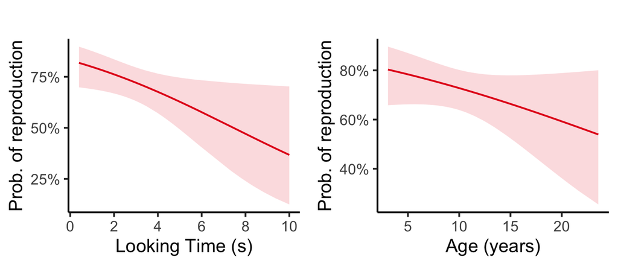

**Discussion question:** Can you interpret all the components of the new model output?

**FIN**

**Acknowledgements:** The creation of this module was funded by the National Science Foundation DBI BRC-BIO award 2217812. Cayo Santiago is supported by the Office of Research Infrastructure Programs (ORIP) of the National Institutes of Health, grant 2 P40 OD012217, and the University of Puerto Rico (UPR), Medical Sciences Campus. Additional support was provided by the National Science Foundation Graduate Research Fellowship Program to Alexis A. Diaz, award 2141410.

[figure not shown]

**Authors:** Alexis A. Diaz, Raisa Hernández-Pacheco, Alexandra L. Bland, and Alexandra G. Rosati, California State University, Long Beach, University of Michigan